# Optimal Treatment Analysis

## Outcome Variable

**Outcome Variable:** haz

## Predictor Variables

**Intervention Variable:** perdiar24

**Adjustment Set:**

- arm
- sex
- meducyrs
- feducyrs
- hhwealth_quart
- hfoodsec
- vagbrth
- hdlvry
- W_birthwt
- W_birthlen
- single
- W_nrooms
- month
- brthmon
- impfloor
- impsan
- safeh20
- delta_meducyrs
- delta_feducyrs
- delta_hhwealth_quart
- delta_hfoodsec
- delta_vagbrth
- delta_hdlvry
- delta_W_birthwt
- delta_W_birthlen
- delta_single
- delta_W_nrooms
- delta_month
- delta_brthmon
- delta_impfloor
- delta_impsan
- delta_safeh20

## Stratifying Variables

The analysis was stratified on these variable(s):

- agecat
- studyid
- country

## Data Summary

| agecat | studyid | country | perdiar24 | n_cell | n |
| --- | --- | --- | --- | --- | --- |
| Birth | ki0047075b-MAL-ED | BANGLADESH | 0% | 18 | 231 |
| Birth | ki0047075b-MAL-ED | BANGLADESH | (0%, 5%] | 131 | 231 |
| Birth | ki0047075b-MAL-ED | BANGLADESH | >5% | 82 | 231 |
| Birth | ki0047075b-MAL-ED | BRAZIL | 0% | 34 | 65 |
| Birth | ki0047075b-MAL-ED | BRAZIL | (0%, 5%] | 29 | 65 |
| Birth | ki0047075b-MAL-ED | BRAZIL | >5% | 2 | 65 |
| Birth | ki0047075b-MAL-ED | INDIA | 0% | 5 | 47 |
| Birth | ki0047075b-MAL-ED | INDIA | (0%, 5%] | 33 | 47 |
| Birth | ki0047075b-MAL-ED | INDIA | >5% | 9 | 47 |
| Birth | ki0047075b-MAL-ED | NEPAL | 0% | 2 | 27 |
| Birth | ki0047075b-MAL-ED | NEPAL | (0%, 5%] | 19 | 27 |
| Birth | ki0047075b-MAL-ED | NEPAL | >5% | 6 | 27 |
| Birth | ki0047075b-MAL-ED | PERU | 0% | 21 | 233 |
| Birth | ki0047075b-MAL-ED | PERU | (0%, 5%] | 89 | 233 |
| Birth | ki0047075b-MAL-ED | PERU | >5% | 123 | 233 |
| Birth | ki0047075b-MAL-ED | SOUTH AFRICA | 0% | 42 | 113 |
| Birth | ki0047075b-MAL-ED | SOUTH AFRICA | (0%, 5%] | 70 | 113 |
| Birth | ki0047075b-MAL-ED | SOUTH AFRICA | >5% | 1 | 113 |
| Birth | ki0047075b-MAL-ED | TANZANIA, UNITED REPUBLIC OF | 0% | 9 | 125 |
| Birth | ki0047075b-MAL-ED | TANZANIA, UNITED REPUBLIC OF | (0%, 5%] | 85 | 125 |
| Birth | ki0047075b-MAL-ED | TANZANIA, UNITED REPUBLIC OF | >5% | 31 | 125 |
| Birth | ki1000109-EE | PAKISTAN | 0% | 161 | 240 |
| Birth | ki1000109-EE | PAKISTAN | (0%, 5%] | 79 | 240 |
| Birth | ki1000109-EE | PAKISTAN | >5% | 0 | 240 |
| Birth | ki1017093-NIH-Birth | BANGLADESH | 0% | 51 | 605 |
| Birth | ki1017093-NIH-Birth | BANGLADESH | (0%, 5%] | 345 | 605 |
| Birth | ki1017093-NIH-Birth | BANGLADESH | >5% | 209 | 605 |
| Birth | ki1017093b-PROVIDE | BANGLADESH | 0% | 55 | 539 |
| Birth | ki1017093b-PROVIDE | BANGLADESH | (0%, 5%] | 327 | 539 |
| Birth | ki1017093b-PROVIDE | BANGLADESH | >5% | 157 | 539 |

[output cut: 102 more lines]

The following strata were considered:

- agecat: 24 months, studyid: ki0047075b-MAL-ED, country: BANGLADESH
- agecat: 24 months, studyid: ki0047075b-MAL-ED, country: BRAZIL
- agecat: 24 months, studyid: ki0047075b-MAL-ED, country: INDIA
- agecat: 24 months, studyid: ki0047075b-MAL-ED, country: NEPAL
- agecat: 24 months, studyid: ki0047075b-MAL-ED, country: PERU
- agecat: 24 months, studyid: ki0047075b-MAL-ED, country: SOUTH AFRICA
- agecat: 24 months, studyid: ki0047075b-MAL-ED, country: TANZANIA, UNITED REPUBLIC OF
- agecat: 24 months, studyid: ki1000109-EE, country: PAKISTAN
- agecat: 24 months, studyid: ki1017093-NIH-Birth, country: BANGLADESH
- agecat: 24 months, studyid: ki1017093b-PROVIDE, country: BANGLADESH
- agecat: 24 months, studyid: ki1017093c-NIH-Crypto, country: BANGLADESH
- agecat: 24 months, studyid: ki1114097-CMIN, country: BANGLADESH
- agecat: 24 months, studyid: ki1114097-CONTENT, country: PERU
- agecat: 24 months, studyid: kiGH5241-JiVitA-4, country: BANGLADESH
- agecat: 6 months, studyid: ki0047075b-MAL-ED, country: BANGLADESH
- agecat: 6 months, studyid: ki0047075b-MAL-ED, country: BRAZIL
- agecat: 6 months, studyid: ki0047075b-MAL-ED, country: INDIA
- agecat: 6 months, studyid: ki0047075b-MAL-ED, country: NEPAL
- agecat: 6 months, studyid: ki0047075b-MAL-ED, country: PERU
- agecat: 6 months, studyid: ki0047075b-MAL-ED, country: SOUTH AFRICA
- agecat: 6 months, studyid: ki0047075b-MAL-ED, country: TANZANIA, UNITED REPUBLIC OF
- agecat: 6 months, studyid: ki1000109-EE, country: PAKISTAN
- agecat: 6 months, studyid: ki1000304b-SAS-FoodSuppl, country: INDIA
- agecat: 6 months, studyid: ki1017093-NIH-Birth, country: BANGLADESH
- agecat: 6 months, studyid: ki1017093b-PROVIDE, country: BANGLADESH
- agecat: 6 months, studyid: ki1017093c-NIH-Crypto, country: BANGLADESH
- agecat: 6 months, studyid: ki1112895-Guatemala BSC, country: GUATEMALA
- agecat: 6 months, studyid: ki1114097-CMIN, country: BANGLADESH
- agecat: 6 months, studyid: ki1114097-CONTENT, country: PERU
- agecat: 6 months, studyid: kiGH5241-JiVitA-4, country: BANGLADESH
- agecat: Birth, studyid: ki0047075b-MAL-ED, country: BANGLADESH
- agecat: Birth, studyid: ki0047075b-MAL-ED, country: BRAZIL
- agecat: Birth, studyid: ki0047075b-MAL-ED, country: INDIA
- agecat: Birth, studyid: ki0047075b-MAL-ED, country: NEPAL
- agecat: Birth, studyid: ki0047075b-MAL-ED, country: PERU
- agecat: Birth, studyid: ki0047075b-MAL-ED, country: SOUTH AFRICA
- agecat: Birth, studyid: ki0047075b-MAL-ED, country: TANZANIA, UNITED REPUBLIC OF
- agecat: Birth, studyid: ki1000109-EE, country: PAKISTAN
- agecat: Birth, studyid: ki1017093-NIH-Birth, country: BANGLADESH
- agecat: Birth, studyid: ki1017093b-PROVIDE, country: BANGLADESH
- agecat: Birth, studyid: ki1017093c-NIH-Crypto, country: BANGLADESH
- agecat: Birth, studyid: ki1114097-CMIN, country: BANGLADESH
- agecat: Birth, studyid: ki1114097-CONTENT, country: PERU
- agecat: Birth, studyid: kiGH5241-JiVitA-4, country: BANGLADESH

### Dropped Strata

Some strata were dropped due to rare outcomes:

- agecat: Birth, studyid: ki0047075b-MAL-ED, country: BRAZIL
- agecat: Birth, studyid: ki0047075b-MAL-ED, country: NEPAL
- agecat: Birth, studyid: ki0047075b-MAL-ED, country: SOUTH AFRICA
- agecat: Birth, studyid: ki1000109-EE, country: PAKISTAN
- agecat: Birth, studyid: ki1114097-CMIN, country: BANGLADESH
- agecat: Birth, studyid: ki1114097-CONTENT, country: PERU
- agecat: 6 months, studyid: ki0047075b-MAL-ED, country: BRAZIL
- agecat: 6 months, studyid: ki0047075b-MAL-ED, country: INDIA
- agecat: 6 months, studyid: ki0047075b-MAL-ED, country: SOUTH AFRICA
- agecat: 6 months, studyid: ki1000109-EE, country: PAKISTAN
- agecat: 6 months, studyid: ki1114097-CMIN, country: BANGLADESH
- agecat: 24 months, studyid: ki0047075b-MAL-ED, country: BRAZIL
- agecat: 24 months, studyid: ki0047075b-MAL-ED, country: INDIA
- agecat: 24 months, studyid: ki0047075b-MAL-ED, country: PERU
- agecat: 24 months, studyid: ki0047075b-MAL-ED, country: SOUTH AFRICA
- agecat: 24 months, studyid: ki1000109-EE, country: PAKISTAN
- agecat: 24 months, studyid: ki1114097-CMIN, country: BANGLADESH
- agecat: 24 months, studyid: ki1114097-CONTENT, country: PERU

## Methods Detail

We’re interested in the causal parameters $E[Y_a]$ for all values of $a \in \mathcal{A}$. These parameters represent the mean outcome if, possibly contrary to fact, we intervened to set all units to have $A=a$. Under the randomization and positivity assumptions, these are identified by the statistical parameters $\psi_a=E_W[E_{Y|A,W}(Y|A=a,W)]$. In addition, we’re interested in the mean of $Y$, $E[Y]$ under no intervention (the observed mean). We will estimate these parameters by using SuperLearner to fit the relevant likelihood factors – $E_{Y|A,W}(Y|A=a,W)$ and $p(A=a|W)$, and then updating our likelihood fit using a joint TMLE.

For unadjusted analyses ($W=\{\}$), initial likelihoods were estimated using Lrnr_glm to estimate the simple $E(Y|A)$ and Lrnr_mean to estimate $p(A)$. For adjusted analyses, a small library containing Lrnr_glmnet, Lrnr_xgboost, and Lrnr_mean was used.

# Results Detail

## Results Plots

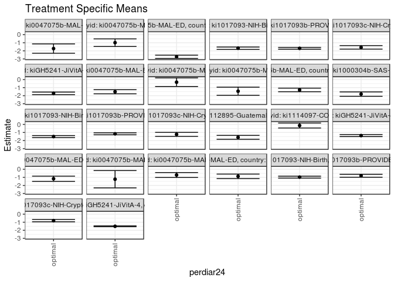

## Results Table

### Parameter: TSM

| agecat | studyid | country | intervention_level | baseline_level | estimate | ci_lower | ci_upper |
| --- | --- | --- | --- | --- | --- | --- | --- |
| Birth | ki0047075b-MAL-ED | BANGLADESH | optimal | observed | -1.1721082 | -1.4936773 | -0.8505392 |
| Birth | ki0047075b-MAL-ED | INDIA | optimal | observed | -1.2318031 | -2.3035089 | -0.1600972 |
| Birth | ki0047075b-MAL-ED | PERU | optimal | observed | -0.7092409 | -1.0112221 | -0.4072596 |
| Birth | ki0047075b-MAL-ED | TANZANIA, UNITED REPUBLIC OF | optimal | observed | -0.8718468 | -1.1492626 | -0.5944311 |
| Birth | ki1017093-NIH-Birth | BANGLADESH | optimal | observed | -0.9728002 | -1.0919134 | -0.8536869 |
| Birth | ki1017093b-PROVIDE | BANGLADESH | optimal | observed | -0.7983950 | -0.9802839 | -0.6165062 |
| Birth | ki1017093c-NIH-Crypto | BANGLADESH | optimal | observed | -0.8043896 | -0.9484549 | -0.6603242 |
| Birth | kiGH5241-JiVitA-4 | BANGLADESH | optimal | observed | -1.5044776 | -1.5574004 | -1.4515548 |
| 6 months | ki0047075b-MAL-ED | BANGLADESH | optimal | observed | -1.5101742 | -1.7698100 | -1.2505384 |
| 6 months | ki0047075b-MAL-ED | NEPAL | optimal | observed | -0.3280857 | -0.8589421 | 0.2027708 |
| 6 months | ki0047075b-MAL-ED | PERU | optimal | observed | -1.4422687 | -1.9441026 | -0.9404349 |
| 6 months | ki0047075b-MAL-ED | TANZANIA, UNITED REPUBLIC OF | optimal | observed | -1.2865786 | -1.5093662 | -1.0637909 |
| 6 months | ki1000304b-SAS-FoodSuppl | INDIA | optimal | observed | -1.8022908 | -2.0748988 | -1.5296827 |
| 6 months | ki1017093-NIH-Birth | BANGLADESH | optimal | observed | -1.5058013 | -1.6322265 | -1.3793760 |
| 6 months | ki1017093b-PROVIDE | BANGLADESH | optimal | observed | -1.1644149 | -1.2896712 | -1.0391586 |
| 6 months | ki1017093c-NIH-Crypto | BANGLADESH | optimal | observed | -1.2324640 | -1.4814220 | -0.9835060 |
| 6 months | ki1112895-Guatemala BSC | GUATEMALA | optimal | observed | -1.5959359 | -1.8371800 | -1.3546919 |
| 6 months | ki1114097-CONTENT | PERU | optimal | observed | -0.1363862 | -0.4427342 | 0.1699618 |
| 6 months | kiGH5241-JiVitA-4 | BANGLADESH | optimal | observed | -1.3824507 | -1.5089475 | -1.2559538 |
| 24 months | ki0047075b-MAL-ED | BANGLADESH | optimal | observed | -1.7191656 | -2.2971051 | -1.1412261 |
| 24 months | ki0047075b-MAL-ED | NEPAL | optimal | observed | -0.9890809 | -1.4582254 | -0.5199364 |
| 24 months | ki0047075b-MAL-ED | TANZANIA, UNITED REPUBLIC OF | optimal | observed | -2.7361461 | -2.9369823 | -2.5353099 |
| 24 months | ki1017093-NIH-Birth | BANGLADESH | optimal | observed | -1.6738821 | -1.8194093 | -1.5283549 |
| 24 months | ki1017093b-PROVIDE | BANGLADESH | optimal | observed | -1.6880780 | -1.7980933 | -1.5780626 |
| 24 months | ki1017093c-NIH-Crypto | BANGLADESH | optimal | observed | -1.5694611 | -1.7874642 | -1.3514581 |
| 24 months | kiGH5241-JiVitA-4 | BANGLADESH | optimal | observed | -1.7111706 | -1.8723322 | -1.5500091 |

### Parameter: E(Y)

| agecat | studyid | country | intervention_level | baseline_level | estimate | ci_lower | ci_upper |
| --- | --- | --- | --- | --- | --- | --- | --- |
| Birth | ki0047075b-MAL-ED | BANGLADESH | observed | observed | -1.1180952 | -1.2525408 | -0.9836496 |
| Birth | ki0047075b-MAL-ED | INDIA | observed | observed | -1.2036170 | -1.4976814 | -0.9095527 |
| Birth | ki0047075b-MAL-ED | PERU | observed | observed | -0.8827897 | -1.0001058 | -0.7654736 |
| Birth | ki0047075b-MAL-ED | TANZANIA, UNITED REPUBLIC OF | observed | observed | -1.1556000 | -1.3655361 | -0.9456639 |
| Birth | ki1017093-NIH-Birth | BANGLADESH | observed | observed | -0.9314050 | -1.0202164 | -0.8425936 |
| Birth | ki1017093b-PROVIDE | BANGLADESH | observed | observed | -0.8851020 | -0.9601332 | -0.8100709 |
| Birth | ki1017093c-NIH-Crypto | BANGLADESH | observed | observed | -0.9094945 | -0.9809370 | -0.8380521 |
| Birth | kiGH5241-JiVitA-4 | BANGLADESH | observed | observed | -1.5232908 | -1.5723277 | -1.4742539 |
| 6 months | ki0047075b-MAL-ED | BANGLADESH | observed | observed | -1.2049931 | -1.3222136 | -1.0877726 |
| 6 months | ki0047075b-MAL-ED | NEPAL | observed | observed | -0.5615819 | -0.6741832 | -0.4489807 |
| 6 months | ki0047075b-MAL-ED | PERU | observed | observed | -1.3236661 | -1.4316775 | -1.2156546 |
| 6 months | ki0047075b-MAL-ED | TANZANIA, UNITED REPUBLIC OF | observed | observed | -1.3687449 | -1.4907629 | -1.2467270 |
| 6 months | ki1000304b-SAS-FoodSuppl | INDIA | observed | observed | -1.8986842 | -2.0118892 | -1.7854792 |
| 6 months | ki1017093-NIH-Birth | BANGLADESH | observed | observed | -1.4073821 | -1.4960598 | -1.3187043 |
| 6 months | ki1017093b-PROVIDE | BANGLADESH | observed | observed | -1.0916915 | -1.1661176 | -1.0172654 |
| 6 months | ki1017093c-NIH-Crypto | BANGLADESH | observed | observed | -1.1986783 | -1.2700937 | -1.1272630 |
| 6 months | ki1112895-Guatemala BSC | GUATEMALA | observed | observed | -1.5619008 | -1.6727702 | -1.4510313 |
| 6 months | ki1114097-CONTENT | PERU | observed | observed | -0.3139217 | -0.4868486 | -0.1409948 |
| 6 months | kiGH5241-JiVitA-4 | BANGLADESH | observed | observed | -1.3447940 | -1.3820261 | -1.3075620 |
| 24 months | ki0047075b-MAL-ED | BANGLADESH | observed | observed | -1.9783962 | -2.1050210 | -1.8517715 |
| 24 months | ki0047075b-MAL-ED | NEPAL | observed | observed | -1.3075877 | -1.4270718 | -1.1881037 |
| 24 months | ki0047075b-MAL-ED | TANZANIA, UNITED REPUBLIC OF | observed | observed | -2.6455607 | -2.7807256 | -2.5103959 |
| 24 months | ki1017093-NIH-Birth | BANGLADESH | observed | observed | -2.2190579 | -2.3217459 | -2.1163699 |
| 24 months | ki1017093b-PROVIDE | BANGLADESH | observed | observed | -1.6024221 | -1.6857420 | -1.5191023 |
| 24 months | ki1017093c-NIH-Crypto | BANGLADESH | observed | observed | -1.4412646 | -1.5249156 | -1.3576135 |
| 24 months | kiGH5241-JiVitA-4 | BANGLADESH | observed | observed | -1.7807218 | -1.8162478 | -1.7451958 |

### Parameter: PAR

| agecat | studyid | country | intervention_level | baseline_level | estimate | ci_lower | ci_upper |
| --- | --- | --- | --- | --- | --- | --- | --- |
| Birth | ki0047075b-MAL-ED | BANGLADESH | optimal | observed | 0.0540130 | -0.2241630 | 0.3321890 |
| Birth | ki0047075b-MAL-ED | INDIA | optimal | observed | 0.0281861 | -0.9690504 | 1.0254226 |
| Birth | ki0047075b-MAL-ED | PERU | optimal | observed | -0.1735488 | -0.4577124 | 0.1106148 |
| Birth | ki0047075b-MAL-ED | TANZANIA, UNITED REPUBLIC OF | optimal | observed | -0.2837532 | -0.5748703 | 0.0073640 |
| Birth | ki1017093-NIH-Birth | BANGLADESH | optimal | observed | 0.0413952 | -0.0429917 | 0.1257820 |
| Birth | ki1017093b-PROVIDE | BANGLADESH | optimal | observed | -0.0867070 | -0.2550712 | 0.0816572 |
| Birth | ki1017093c-NIH-Crypto | BANGLADESH | optimal | observed | -0.1051050 | -0.2395491 | 0.0293392 |
| Birth | kiGH5241-JiVitA-4 | BANGLADESH | optimal | observed | -0.0188132 | -0.0375218 | -0.0001046 |
| 6 months | ki0047075b-MAL-ED | BANGLADESH | optimal | observed | 0.3051811 | 0.0366716 | 0.5736906 |
| 6 months | ki0047075b-MAL-ED | NEPAL | optimal | observed | -0.2334963 | -0.7470776 | 0.2800850 |
| 6 months | ki0047075b-MAL-ED | PERU | optimal | observed | 0.1186027 | -0.3814171 | 0.6186224 |
| 6 months | ki0047075b-MAL-ED | TANZANIA, UNITED REPUBLIC OF | optimal | observed | -0.0821664 | -0.2830221 | 0.1186894 |
| 6 months | ki1000304b-SAS-FoodSuppl | INDIA | optimal | observed | -0.0963934 | -0.3567117 | 0.1639249 |
| 6 months | ki1017093-NIH-Birth | BANGLADESH | optimal | observed | 0.0984192 | 0.0074378 | 0.1894007 |
| 6 months | ki1017093b-PROVIDE | BANGLADESH | optimal | observed | 0.0727234 | -0.0243249 | 0.1697716 |
| 6 months | ki1017093c-NIH-Crypto | BANGLADESH | optimal | observed | 0.0337857 | -0.2022107 | 0.2697821 |
| 6 months | ki1112895-Guatemala BSC | GUATEMALA | optimal | observed | 0.0340352 | -0.1915939 | 0.2596643 |
| 6 months | ki1114097-CONTENT | PERU | optimal | observed | -0.1775355 | -0.4353353 | 0.0802643 |
| 6 months | kiGH5241-JiVitA-4 | BANGLADESH | optimal | observed | 0.0376566 | -0.0819804 | 0.1572937 |
| 24 months | ki0047075b-MAL-ED | BANGLADESH | optimal | observed | -0.2592306 | -0.8373248 | 0.3188636 |
| 24 months | ki0047075b-MAL-ED | NEPAL | optimal | observed | -0.3185068 | -0.7800288 | 0.1430151 |
| 24 months | ki0047075b-MAL-ED | TANZANIA, UNITED REPUBLIC OF | optimal | observed | 0.0905854 | -0.0459089 | 0.2270796 |
| 24 months | ki1017093-NIH-Birth | BANGLADESH | optimal | observed | -0.5451757 | -0.7208123 | -0.3695392 |
| 24 months | ki1017093b-PROVIDE | BANGLADESH | optimal | observed | 0.0856558 | 0.0086126 | 0.1626991 |
| 24 months | ki1017093c-NIH-Crypto | BANGLADESH | optimal | observed | 0.1281965 | -0.0618156 | 0.3182087 |
| 24 months | kiGH5241-JiVitA-4 | BANGLADESH | optimal | observed | -0.0695512 | -0.2236959 | 0.0845936 |